# daily wow tag quicklook update

wrc

2025-06-17

# 1 NOTES

additional diagnostics:

- detailed look at tx info

# 2 setup

Run this daily to get a snapshot of tag stats and health

## 2.1 PATH TO LATEST DATA

```r
# paths to update when you run
portaldir <- "../../01_data/portal_downloads_2025/"
metadatapath <- "../../01_data/quicklookmeta.csv"
datadirss <- list.files(portaldir)
datadir <- file.path(portaldir, datadirss[length(datadirss)])
```

## 2.2 basic helper function

## 2.3 load paths adjust as needed

## 2.4 Import data from wildlife portal and the goniometer. Merge the two stacks.

disabled still need goniometer from second boat

# 3 tag summary

|  | ptt | hex | serial | tag_model | deployid | catalog_id | WOW_season | deploydate_yyyymmdd | deploytime_hhmm_local | deploytime_hhmm_utc | species | location | tagger | permit | tagtype | longitude | latitude | tagside | taglocation | taglocationnotes | programming_basic_descriptor | notes | recorder | age | sex | agesex_conf | headshot | agesex_reason | appearance_notes |
| --- | --- | --- | --- | --- | --- | --- | --- | --- | --- | --- | --- | --- | --- | --- | --- | --- | --- | --- | --- | --- | --- | --- | --- | --- | --- | --- | --- | --- | --- |
| 18 | 285148 | AC073C7 | 24A1404 | SPLASH10-333 | BpTag09 |  | WOW3 | 20250603 | 1500 | 1900 | Bph | NYB | JMA | Engelhaupt | NA | NA | NA |  |  |  | NA | time approx | NA | NA | NA | NA | NA | NA | NA |

# 4 calculate stats

# 5 summaries

## 5.1 status and corrupt

| deployid | ptt | nmsg | ncrc | transmits | battvoltrange | zerodepthrange | last_sta_recieved | ncorrupt |
| --- | --- | --- | --- | --- | --- | --- | --- | --- |
| BpTag09 | 285148 | 29 | 29 | 7214 | 3.504 to 3.568 | 0 to 3 | 2025-06-17 02:44:43 | 259 |

## 5.2 locations

| deployid | ptt | nloc | nz | na | nb | n0 | n1 | n2 | n3 | last_loc_recieved | deployed_hours | pos_per_hour |
| --- | --- | --- | --- | --- | --- | --- | --- | --- | --- | --- | --- | --- |
| BpTag09 | 285148 | 204 | 1 | 28 | 67 | 67 | 27 | 8 | 6 | 2025-06-17 11:06:35 | 347 | 0.59 |

## 5.3 behavior

| deployid | ptt | n_beh_msgs | totalbeh_time_hours | nbehgaps | behgap_time_hours | latest_beh_recieved |
| --- | --- | --- | --- | --- | --- | --- |
| BpTag09 | 285148 | 194 | 207.3006 | 41 | 107.8667 | 2025-06-16 23:27:28 |

## 5.4 series

n/a

## 5.5 fastloc

n/a

# 6 position snapshot

Plot of the last four positions for all the tags which have generated an argos position within the last 3 days

[interactive chart not shown]

# 7 plot pressure sensors

**PROVISIONAL** plot status cutoffs and bat voltage. Cutoffs are in dotted red lines. These are either:

1. healthy tags: the last status messages as a conservative cutoff and on tags that are still actively transmitting this is likely to increase
2. unhealthy pressure transducer tags: if there are 2 status messages (crc’d) where the | zerodepth | > 10 then this is the last good status message before the 1st of those two bad messages.

We have settled on a more complicated cutoff system to capture a little more very likely good data for BRS (ask wrc for details). But this gives you a general idea of approx. cutoffs and pressure transducer health.

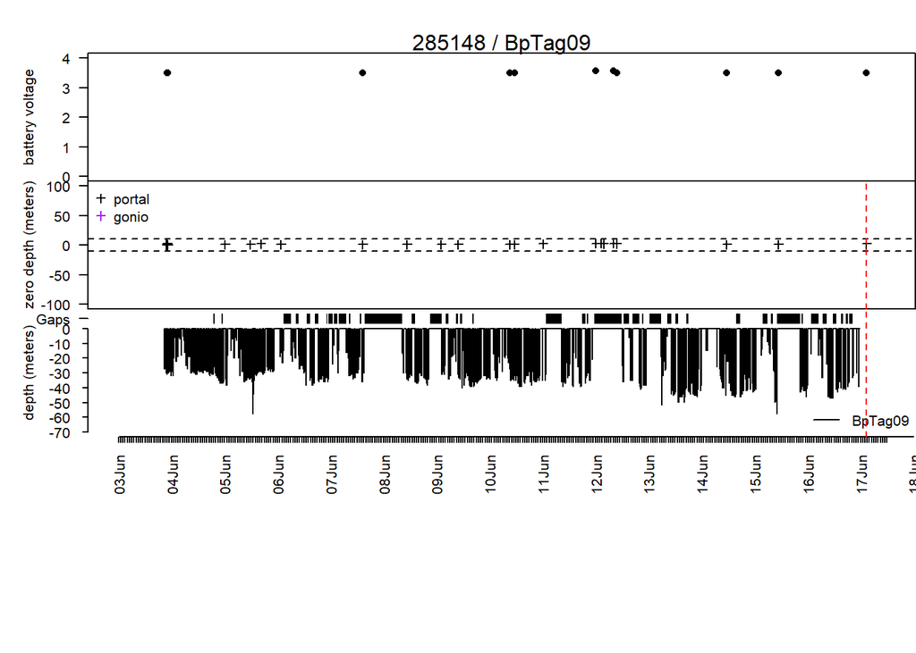

# 8 all positions

‘all’ = just qual = {0, 1, 2, 3} except for bp01 because it only hit As and Bs.

[interactive chart not shown]